Ullrich Köthe: Fundamentals of Machine Learning, Winter Semester 2017/18  
Notebook created by Nicolas Roth

# Solutions for Exercise 6

```python
import numpy as np
%matplotlib inline
import matplotlib.pyplot as plt

import pandas as pd
pd.options.display.float_format = '{:,.2f}'.format
def fade_zeros(s):
    return ['color: lightgray' if v else 'color: black' for v in (0 == s)]
from IPython.display import display
```

# 1.) Bias and variance of ridge regression

Probably on blackboard so everyone can follow the calculations...

Ridge regression solves: \begin{align} \hat{\beta}_\tau =& \text{argmin}_\beta ||X \beta -\tau||^2_F + \tau ||\beta||^2_2 \\ =& \text{argmin}_\beta (X \beta - y)^T (X \beta - y) + \tau ||\beta||^2_2 \end{align}

**Prove, that:** \begin{align} \mathbb{E}[\hat{\beta}_\tau] &= S_\tau^{-1} S \beta^* \\ \text{Var}[\hat{\beta}_\tau] &= S_\tau^{-2} S \sigma^2 \end{align}

with *scatter matrices* $S = X^T X$ and $S_\tau = X^T X + \tau \mathbb{1}$

Find the minimum by calculating $\partial_\beta$Loss $\overset{!}{=}0$: \begin{align} 2 X^T X \hat{\beta}_\tau - 2X^T y + 2 \tau \hat{\beta}_\tau &= 0 \\ (X^T X + \tau \mathbb{1}) \hat{\beta}_\tau &= X^T y \\ \hat{\beta}_\tau &= S_\tau^{-1} X^T y\\ \end{align}

True model: $y=X \beta^* + \epsilon$

\begin{align} \hat{\beta}_\tau &= S_\tau^{-1} X^T (X \beta^* + \epsilon) \\ \hat{\beta}_\tau &= S_\tau^{-1} S \beta^* + S_\tau^{-1} X^T \epsilon \end{align}

Now, take the expectancy value:

\begin{align} \mathbb{E}[\hat{\beta}] &= \mathbb{E}[S_\tau^{-1} S \beta^*] + \mathbb{E}[S_\tau^{-1} X^T\epsilon]\\ &= S_\tau^{-1} S \beta^* + S_\tau^{-1} X^T \mathbb{E}[\epsilon] \\ &= S_\tau^{-1} S \beta^* \quad \square \end{align}

Calculate Covariance:

\begin{align} \text{Cov}[\hat{\beta}_\tau] = \text{Cov}[\hat{\beta}_\tau,\hat{\beta}_\tau] &= \mathbb{E}\big[(\hat{\beta}_\tau - \mathbb{E}[\hat{\beta}_\tau]) \cdot (\hat{\beta}_\tau - \mathbb{E}[\hat{\beta}_\tau])^T \big] \\ &= \mathbb{E}\big[(\hat{\beta}_\tau - S_\tau^{-1} S \beta^*) \cdot (\hat{\beta}_\tau - S_\tau^{-1} S \beta^*)^T \big] \\ &= \mathbb{E}\big[ (S_\tau^{-1} X^T \epsilon) \cdot (S_\tau^{-1} X^T \epsilon)^T \big] \\ &= \mathbb{E}\big[ S_\tau^{-1} X^T \epsilon \epsilon^T X S_\tau^{-1 T} \big] \\ &= S_\tau^{-1} S S_\tau^{-1 T} \mathbb{E}[\epsilon \epsilon^T] \\ &= S_\tau^{-2} S \sigma^2 \quad \square \end{align}

BUT: Why is $[S, S_\tau^{-1 T}] = 0$?

\begin{align} [S, S_\tau] = [S,S] + \tau [S, \mathbb{1}] &= 0 \\ [S, \mathbb{1}] = [S, S_\tau S_\tau^{-1}] &= 0 \\ \Rightarrow \quad \ [S, S_\tau^{-1}] &= 0 \\ \overset{sym}{\Rightarrow} \quad [S, S_\tau^{-1 T}] &= 0 \end{align}

# 2.) Denoising of a CT image

Use solution from last week - with only one small tweak...

```python
from scipy.sparse.linalg import lsqr
from scipy.sparse import dok_matrix, coo_matrix, vstack, eye

def construct_X(M, alphas, Np = None, tau=0):
    D = M*M
    # define sensor size
    if Np is None:
        Np = int(np.ceil(np.sqrt(2) * M))
        if Np % 2 == 0: Np += 1
    # number of angles
    No = len(alphas)

    # flattened output coordinates
    j = np.mgrid[0:D].astype(np.int32)
    # coordinate matrix for the output pixels
    M2 = (M-1) / 2
    grid = np.mgrid[-M2:M-M2,-M2:M-M2].swapaxes(1,2).reshape(2,D)

    # collect indices and corresponding values for all iterations
    i_indices = []
    j_indices = []
    weights = []

    for k, alpha in enumerate(alphas):
        # convert angle and prepare projection vector
        alph_rad = np.radians(alpha)
        proj_vec = np.array([np.cos(alph_rad), -np.sin(alph_rad)])
        # project coordinates
        proj = np.dot(proj_vec, grid) + Np // 2
        # compute sensor indices and weights below the projected points
        i = np.floor(proj)
        w = (i+1) - proj

        # make sure rays falling outside the sensor are not counted
        clip = np.logical_and(0 <= i, i < Np-1)

        i_indices.append((i + k*Np)[clip])
        j_indices.append(j[clip])
        weights.append(w[clip])
        # compute sensor indices and weights above the projected points
        w = proj - i
        i_indices.append((i+1 + k*Np)[clip])
        j_indices.append(j[clip])
        weights.append(w[clip])

    # construct matrix X
    i = np.concatenate(i_indices).astype(np.int32)
    j = np.concatenate(j_indices).astype(np.int32)
    w = np.concatenate(weights)
    X = coo_matrix((w, (i,j)), shape = (No*Np, D), dtype = np.float32)

    # append diag(sqrt(tau)) for regularization
    if tau > 0:
        reg = np.sqrt(tau)*eye(M*M)
        X = vstack([X,reg])
    return X
```

Reconstruct the tomogram for 64 angles and variations of $\tau$

```
τ = 0, shape of X = (17600, 38025), mean GV = 119.92763181263976
τ = 1, shape of X = (55625, 38025), mean GV = 119.91782488461713
τ = 10, shape of X = (55625, 38025), mean GV = 119.82967990942062
τ = 100, shape of X = (55625, 38025), mean GV = 118.95303321615249
τ = 1000, shape of X = (55625, 38025), mean GV = 110.7951105526207
τ = 10000, shape of X = (55625, 38025), mean GV = 65.61257007577262
```

[figure not shown]

```python
M = 195
Np = 275
y = np.load('hs_tomography/y_195.npy')
alphas = np.load('hs_tomography/alphas_195.npy')
# reconstruct for 64 angles
index = [int(np.ceil(len(alphas) * p/64)) for p in range(64)]
alphas_sub = alphas[index]
y_sub = []
for j in index:
    y_sub.extend(y[j*Np : (j+1)*Np])
y_sub = np.asarray(y_sub)
y_sub_tau = np.hstack((y_sub,np.zeros(M**2)))

tau = [0,1,10,100,1000,10000]
fig, axes = plt.subplots(3, 2, figsize = (16,16))

for i in range(len(tau)):
    X = construct_X(M, alphas_sub, Np, tau=tau[i]).tocsc()
    beta = lsqr(X, y_sub if tau[i] == 0 else y_sub_tau, atol = 1e-5, btol = 1e-5)[0].reshape(195,195)
    axes.flat[i].imshow(beta, vmin = 0, vmax = 255, interpolation = 'nearest', cmap='bone')
    axes.flat[i].set_title('τ = {}'.format(tau[i]))
    axes.flat[i].axis('off')
    print('τ = {}, shape of X = {}, mean GV = {}'.format(tau[i], X.shape, np.mean(beta)))

fig.tight_layout()
plt.show()
```

Compare this with gaussian filtering of different standard deviations: \begin{equation} g(x) = \frac{1}{\sqrt{2 \pi} \sigma} \cdot e^{-\frac{x^2}{2\sigma^2}} \end{equation} Apply 1d-filter in all dimensions (truncate filter after $4\sigma$)

[figure not shown]

```python
from scipy.ndimage.filters import gaussian_filter

X = construct_X(M, alphas_sub, Np, tau=0).tocsc()
beta = lsqr(X, y_sub, atol = 1e-5, btol = 1e-5)[0].reshape(195,195)

sigma = [0,1,2,3,5,7]
fig, axes = plt.subplots(3, 2, figsize = (16,16))

for i in range(len(sigma)):
    beta_smooth = gaussian_filter(beta,sigma[i])
    axes.flat[i].imshow(beta_smooth, vmin = 0, vmax = 255, interpolation = 'nearest', cmap='bone')
    axes.flat[i].set_title('σ = {}'.format(sigma[i]))
    axes.flat[i].axis('off')
    #print(np.mean(beta_smooth))
fig.tight_layout()
plt.show()
```

# 3.) Automatic feature selection for regression

## 3.1) Orthogonal Matching Pursuit

Implement OMP according to algorithm given in the lecture:

```python
from sklearn.datasets import load_digits
from sklearn.model_selection import train_test_split
from numpy.linalg import lstsq

def omp_regression(X, y, T):
    """
    Orthogonal Matching Pursuit iterates T times to automatically find the weights for the
    1...T most relevant features in the training set X (standardized!) with responses y
    It returns the optimal weight vector for every iteration with dimensions DxT
    """
    # initialization
    dim = X.shape[1]
    beta_hat = np.zeros((dim,T))
    A = []
    B = list(range(X.shape[1]))
    res = y
    # iteration
    for t in range(T): # do iteration
        cor = [np.abs(np.dot(X[:,j].T,res)) for j in B] # 1a.) correlations with the current residual
        j_max = np.argmax(np.array(cor)) # 1b.) find maximum
        A.append(B.pop(j_max)) # 2.) move most important dim/feature to active set
        X_active = X[:,A] # 3.) form the active matrix
        #print(A,len(B))
        beta = lstsq(X_active,y) # 4.) solve least squares problem n
        res = y - np.dot(X_active,beta[0]) # 5.) update the residual
        beta_hat[A,t] = beta[0]
        #print(y)

    return beta_hat
```

## 3.2) Classifcation with sparse LDA

Use results of OMP for linear discrimination - again with the digits 1&7 of the **digits** data set.

```python
digits = load_digits()
data = digits["data"]
target = digits["target"]
target_names = digits["target_names"]

def LDA_data(data, target, num_1 = 1, num_2 = 7, test_percentage = 0.33, random_seed=0):
    """
    This function filters two digits from the dataset, standardizes it and randomly splits it in train and test set.
    """
    # Data filering
    mask = np.logical_or(target == num_1, target == num_2)
    data = data[mask]#/data.max()
    # data_std = (data -np.mean(data))/np.std(data) # standardize matrix BUT shouldn't use testdata for that...
    target = target[mask]

    # Relabel targets
    target[target == num_1] = 1
    target[target == num_2] = -1

    # Random Split
    x_training, x_test, y_training, y_test = train_test_split(data, target, test_size=test_percentage,
                                                                      random_state=random_seed)
    train_std = np.std(x_training, axis=0)+1e-99
    train_mean = np.mean(x_training, axis=0)
    # standardize training data (for every dimension, respectively)
    x_training_std = (x_training - train_mean)/train_std
    # standardize test data in SAME WAY
    x_test_std = (x_test - train_mean)/train_std

    return x_training, x_training_std, x_test, x_test_std, y_training, y_test

x_training, x_training_std, x_test, x_test_std, y_training, y_test = LDA_data(data, target)
```

Take a look at standardized data

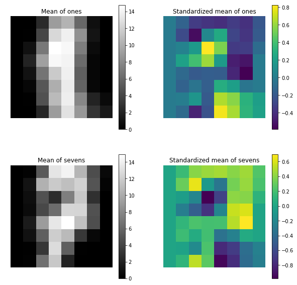

```python
plt.figure(figsize=(10,10))
plt.subplot(221)
plt.imshow(np.array(np.mean(x_training[y_training==1],axis=0)).reshape((8,8)),cmap='gray')
plt.title('Mean of ones')
plt.axis('off'); plt.colorbar()
plt.subplot(222)
plt.title('Standardized mean of ones')
plt.imshow(np.array(np.mean(x_training_std[y_training==1],axis=0)).reshape((8,8)))
plt.axis('off'); plt.colorbar()
plt.subplot(223)
plt.title('Mean of sevens')
plt.imshow(np.array(np.mean(x_training[y_training==-1],axis=0)).reshape((8,8)),cmap='gray')
plt.axis('off'); plt.colorbar()
plt.subplot(224)
plt.title('Standardized mean of sevens')
plt.imshow(np.array(np.mean(x_training_std[y_training==-1],axis=0)).reshape((8,8)))
plt.axis('off'); plt.colorbar()
plt.show()
```

OMP regression for t = 1...15

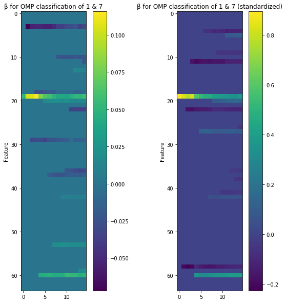

```python
T = 15
beta = omp_regression(x_training, y_training, T)
beta_std = omp_regression(x_training_std, y_training, T)

plt.figure(figsize=(10,10))
plt.subplot(121)
plt.ylabel('Feature')
plt.title('β for OMP classification of 1 & 7')
plt.imshow(beta)
plt.colorbar()

plt.subplot(122)
plt.ylabel('Feature')
plt.imshow(beta_std)
plt.title('β for OMP classification of 1 & 7 (standardized)')
plt.colorbar()
plt.show()
```

| not standard. \| t = | 1 | 2 | 3 | 4 | 5 | 6 | 7 | 8 | 9 | 10 | 11 | 12 | 13 | 14 | 15 |
| --- | --- | --- | --- | --- | --- | --- | --- | --- | --- | --- | --- | --- | --- | --- | --- |
| err_train | 0.54 | 0.96 | 0.98 | 0.97 | 0.99 | 0.99 | 0.99 | 0.99 | 1.00 | 1.00 | 0.99 | 1.00 | 1.00 | 1.00 | 1.00 |
| err_test | 0.42 | 0.95 | 0.96 | 0.98 | 0.99 | 0.99 | 0.99 | 1.00 | 0.99 | 0.99 | 0.99 | 1.00 | 1.00 | 1.00 | 1.00 |

| standardized \| t = | 1 | 2 | 3 | 4 | 5 | 6 | 7 | 8 | 9 | 10 | 11 | 12 | 13 | 14 | 15 |
| --- | --- | --- | --- | --- | --- | --- | --- | --- | --- | --- | --- | --- | --- | --- | --- |
| err_train | 0.95 | 0.98 | 1.00 | 0.99 | 1.00 | 1.00 | 1.00 | 1.00 | 1.00 | 1.00 | 1.00 | 1.00 | 1.00 | 1.00 | 1.00 |
| err_test | 0.97 | 0.97 | 1.00 | 0.99 | 1.00 | 0.99 | 0.99 | 0.99 | 1.00 | 0.99 | 0.99 | 1.00 | 1.00 | 1.00 | 1.00 |

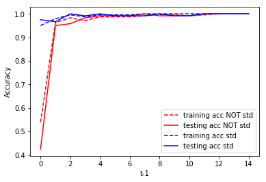

```python
def prediction_acc(testset, beta_vector, label):
    #print(testset.shape, beta_vector.shape)
    pred = np.dot(testset,beta_vector)
    pred[np.where(pred < 0)] = -1
    pred[np.where(pred > 0)] = 1
    return np.mean(pred == label)

accuracy = np.zeros((2,T))
accuracy_std = np.zeros((2,T))
for t in range(T):
    #print(str(t) +' Test acc: '+ str(prediction_acc(x_test,beta[:,t],y_test))+' Training acc: '+ str(prediction_acc(x_training,beta[:,t],y_training)))
    accuracy[0,t] = prediction_acc(x_training,beta[:,t],y_training)
    accuracy[1,t] = prediction_acc(x_test,beta[:,t],y_test)
    accuracy_std[0,t] = prediction_acc(x_training_std,beta_std[:,t],y_training)
    accuracy_std[1,t] = prediction_acc(x_test_std,beta_std[:,t],y_test)

display(pd.DataFrame(
        data = accuracy,
        index = ['err_train', 'err_test'],
        columns = list(range(1,T+1)))
        .rename_axis('not standard. | t =', axis = 'columns'))

display(pd.DataFrame(
        data = accuracy_std,
        index = ['err_train', 'err_test'],
        columns = list(range(1,T+1)))
        .rename_axis('standardized | t =', axis = 'columns'))

plt.plot(accuracy[0,:],'r',linestyle='--', label='training acc NOT std')
plt.plot(accuracy[1,:], 'r', label='testing acc NOT std')
plt.plot(accuracy_std[0,:],'b',linestyle='--', label='training acc std')
plt.plot(accuracy_std[1,:],'b', label='testing acc std')
plt.ylabel('Accuracy')
plt.xlabel('t-1')
plt.legend()
plt.show()
```

Standardization only makes a difference for small $t$, especially for $t=1$  
(...which makes sense!)

Order of the pixels switched to "active":

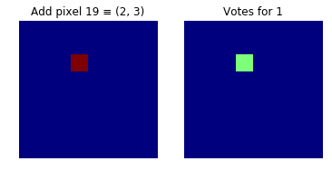

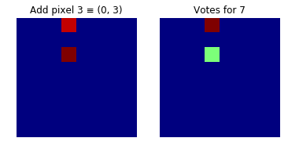

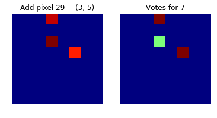

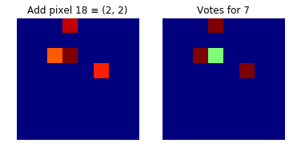

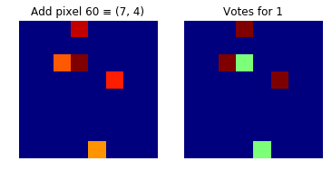

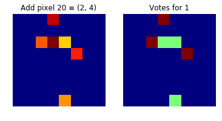

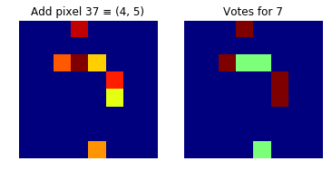

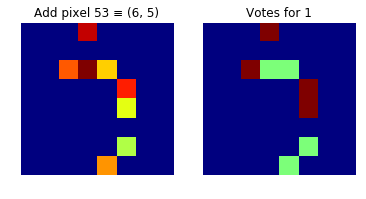

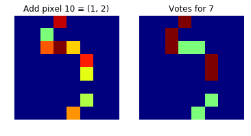

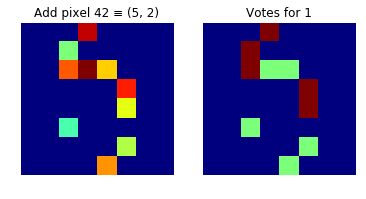

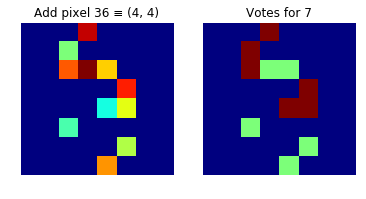

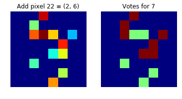

[3 more figures not shown]

```python
def vis_pixel(beta, mean=np.ones(64)):
    '''
    Visualizes the order of pixels getting activated and for what number they are voting
    'mean' only has to be given, if the data was standardized (otherwise it is positive anyway)
    '''
    old_idx = []
    im = np.zeros((8,8))
    im_v = np.zeros((8,8))
    for j in range(beta.shape[1]):
        idx = np.where(beta[:,j]!=0)
        for i in idx[0]:
            if i not in old_idx:
                new = i
                iu = np.unravel_index(i, (8,8))
                im[iu] = beta.shape[1]+1-j
                old_idx.append(i)
                if beta[i,j]*mean[i] > 0:
                    vote = 1
                    im_v[iu] = 1
                else:
                    vote = 7
                    im_v[iu] = 2
        plt.figure()
        plt.subplot(121); plt.axis('off')
        plt.title('Add pixel {} ≡ {}'.format(new,iu))
        plt.imshow(im,vmin=0, vmax=beta.shape[1]+1, cmap='jet')
        plt.subplot(122); plt.axis('off')
        plt.title('Votes for {}'.format(vote))
        plt.imshow(im_v,vmin=0,vmax=2, cmap='jet')

def vis_pixel_singleoutput(beta, mean=np.ones(64)):
    '''
    Same as vis_pixel() but only one output image is generated
    (mostly for exporting to pdf)
    '''
    old_idx = []
    im = np.zeros((8,8))
    im_v = np.zeros((8,8))
    for j in range(beta.shape[1]):
        idx = np.where(beta[:,j]!=0)
        for i in idx[0]:
            if i not in old_idx:
                new = i
                iu = np.unravel_index(i, (8,8))
                im[iu] = j+1
                old_idx.append(i)
                if beta[i,j]*mean[i] > 0:
                    vote = 1
                    im_v[iu] = 1
                else:
                    vote = 7
                    im_v[iu] = 2
    plt.figure(figsize=(12,12))
    plt.subplot(121); plt.axis('off')
    plt.title('Order of pixels switched on (1≡first, ...)')
    plt.imshow(im,vmin=0, vmax=beta.shape[1]+0.5, cmap='jet')
    plt.colorbar(fraction=0.05)
    plt.subplot(122); plt.axis('off')
    plt.title('Vote for: 1=green, 7=red')
    plt.imshow(im_v,vmin=0,vmax=2, cmap='jet')

vis_pixel(beta)
```

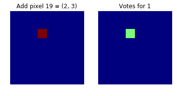

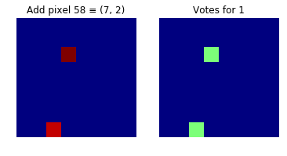

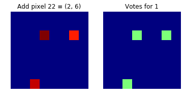

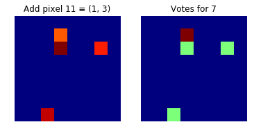

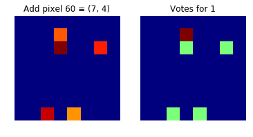

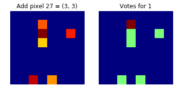

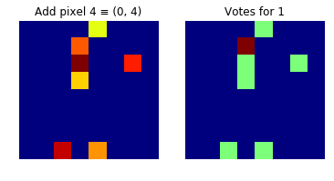

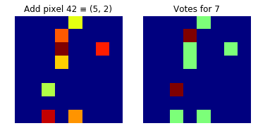

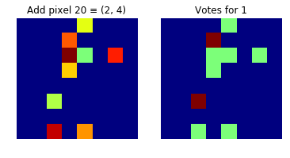

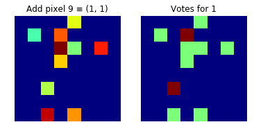

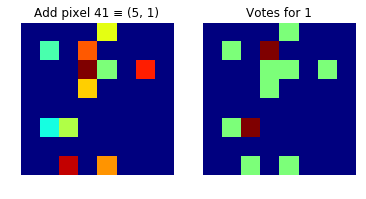

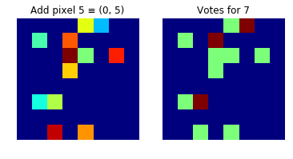

[3 more figures not shown]

```python
vis_pixel(beta_std, np.array(np.mean(x_training_std[y_training==1],axis=0)))
```

## 3.3) One-against-the-rest classifcation

Train $C$ classifiers, trained on $C$ auxillary training sets. Every classifier gives a score for the one class he is trained on. The test instance is assigned the class with the highest score.

```python
from sklearn.utils import shuffle # shuffle arrays in consistent way

def OAR_trainingdata(num, train_data, train_target):
    """
    This function filters one digit from the trainingset (label = 1)
    and combines it with the same amount of other digits (label = -1)
    to the auxilary training set for "class = num"
    """
    train_data, train_target = shuffle(train_data, train_target, random_state=0)
    # Data filering for num
    data_num = train_data[train_target == num]
    target_num = train_target[train_target == num]
    # Data filering for other classes
    data_other = train_data[train_target != num]
    data_other = data_other[:data_num.shape[0],:] # slize for balanced training set!
    target_other = train_target[train_target != num]
    target_other = target_other[:data_num.shape[0]]

    data_train = np.concatenate((data_num,data_other))
    target_train = np.concatenate((target_num,target_other))

    target_train[target_train != num] = -1
    target_train[target_train == num] = 1

    # Random shuffle
    x_training, y_training = shuffle(data_train, target_train, random_state=0)
    return x_training, y_training
```

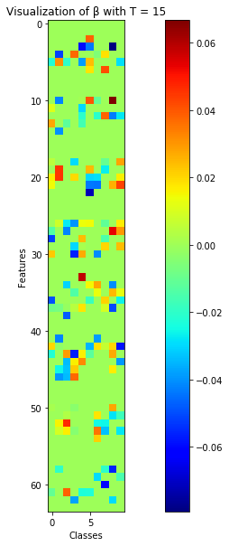

```python
T_OAR = 15 #also show for T_OAR = 2, 10, 15

C = target_names # =[0 1 2 3 4 5 6 7 8 9]
X_training, X_test, Y_training, Y_test = train_test_split(data, target, test_size=0.33, random_state=0)

beta_classes = np.zeros((data.shape[1],len(C))) #  (D x #classes) matrix
# train every classifier with corresponding auxillary training set
for k in C:
    x_temp, y_temp = OAR_trainingdata(k, X_training, Y_training)
    beta_OAR = omp_regression(x_temp, y_temp, T_OAR)
    beta_classes[:,k] = beta_OAR[:,T_OAR-1]

plt.figure(figsize=(16,10))
plt.imshow(beta_classes,cmap='jet')
plt.title('Visualization of β with T = '+str(T_OAR))
plt.xlabel('Classes'); plt.ylabel('Features')
plt.colorbar()
plt.show()
```

If all scores for a test image are negative, assign it the class "unknown" ("unkn") to reduce the amount of false positives.

```python
C_u = np.hstack((C,10))
class_scores = np.zeros((X_test.shape[0],len(C_u)))

for k in C:
    class_scores[:,k] = np.dot(X_test,beta_classes[:,k])

y_predict_u = np.argmax(class_scores,axis=1)
y_predict = np.argmax(class_scores[:,:len(C)],axis=1)

acc = np.mean(y_predict == Y_test)
acc_u = np.mean(y_predict_u == Y_test)

confusion = np.zeros((len(C_u),len(C)))
confusion_u = np.zeros((len(C_u),len(C)))
for i in C_u:
    for j in C:
        confusion_u[i,j] = np.sum((Y_test == j) * (y_predict_u == i)) / np.sum(Y_test == j)
        confusion[i,j] = np.sum((Y_test == j) * (y_predict == i)) / np.sum(Y_test == j)


print('Accuracy of OAR classifier (T = {}) without introduction of "unknown": {}'.format(T_OAR, acc))
display(
    pd.DataFrame(data = confusion[:len(C),:], index = C, columns = C)
    .rename_axis('w/o "unkn"', axis = 'columns')
    .style.apply(fade_zeros)
    .format('{0:.2f}%')
)

print('Accuracy of OAR classifier (T = {}) with introduction of "unknown": {}'.format(T_OAR, acc_u))
display(
    pd.DataFrame(data = confusion_u, index = np.hstack((C,np.nan)), columns = C)
    .rename_axis('w/ "unkn"', axis = 'columns')
    .style.apply(fade_zeros)
    .format('{0:.2f}%')
)
```

```
Accuracy of OAR classifier (T = 15) without introduction of "unknown": 0.9276094276094277
```

| w/o "unkn" | 0 | 1 | 2 | 3 | 4 | 5 | 6 | 7 | 8 | 9 |
| --- | --- | --- | --- | --- | --- | --- | --- | --- | --- | --- |
| 0 | 1.00% | 0.00% | 0.03% | 0.00% | 0.00% | 0.00% | 0.00% | 0.00% | 0.00% | 0.00% |
| 1 | 0.00% | 0.95% | 0.00% | 0.00% | 0.00% | 0.00% | 0.00% | 0.02% | 0.07% | 0.00% |
| 2 | 0.00% | 0.00% | 0.92% | 0.00% | 0.00% | 0.00% | 0.00% | 0.00% | 0.00% | 0.00% |
| 3 | 0.00% | 0.00% | 0.02% | 0.91% | 0.00% | 0.00% | 0.00% | 0.00% | 0.06% | 0.02% |
| 4 | 0.00% | 0.00% | 0.00% | 0.00% | 0.94% | 0.00% | 0.00% | 0.04% | 0.00% | 0.00% |
| 5 | 0.00% | 0.00% | 0.00% | 0.00% | 0.00% | 0.92% | 0.00% | 0.00% | 0.01% | 0.00% |
| 6 | 0.00% | 0.02% | 0.00% | 0.00% | 0.00% | 0.02% | 1.00% | 0.00% | 0.01% | 0.00% |
| 7 | 0.00% | 0.00% | 0.00% | 0.00% | 0.02% | 0.00% | 0.00% | 0.91% | 0.01% | 0.02% |
| 8 | 0.00% | 0.03% | 0.03% | 0.07% | 0.02% | 0.00% | 0.00% | 0.00% | 0.82% | 0.05% |
| 9 | 0.00% | 0.00% | 0.00% | 0.02% | 0.02% | 0.06% | 0.00% | 0.04% | 0.00% | 0.92% |

```
Accuracy of OAR classifier (T = 15) with introduction of "unknown": 0.9276094276094277
```

| w/ "unkn" | 0 | 1 | 2 | 3 | 4 | 5 | 6 | 7 | 8 | 9 |
| --- | --- | --- | --- | --- | --- | --- | --- | --- | --- | --- |
| 0.0 | 1.00% | 0.00% | 0.03% | 0.00% | 0.00% | 0.00% | 0.00% | 0.00% | 0.00% | 0.00% |
| 1.0 | 0.00% | 0.95% | 0.00% | 0.00% | 0.00% | 0.00% | 0.00% | 0.02% | 0.07% | 0.00% |
| 2.0 | 0.00% | 0.00% | 0.92% | 0.00% | 0.00% | 0.00% | 0.00% | 0.00% | 0.00% | 0.00% |
| 3.0 | 0.00% | 0.00% | 0.02% | 0.91% | 0.00% | 0.00% | 0.00% | 0.00% | 0.06% | 0.02% |
| 4.0 | 0.00% | 0.00% | 0.00% | 0.00% | 0.94% | 0.00% | 0.00% | 0.04% | 0.00% | 0.00% |
| 5.0 | 0.00% | 0.00% | 0.00% | 0.00% | 0.00% | 0.92% | 0.00% | 0.00% | 0.01% | 0.00% |
| 6.0 | 0.00% | 0.02% | 0.00% | 0.00% | 0.00% | 0.02% | 1.00% | 0.00% | 0.00% | 0.00% |
| 7.0 | 0.00% | 0.00% | 0.00% | 0.00% | 0.02% | 0.00% | 0.00% | 0.91% | 0.01% | 0.02% |
| 8.0 | 0.00% | 0.03% | 0.03% | 0.05% | 0.02% | 0.00% | 0.00% | 0.00% | 0.82% | 0.05% |
| 9.0 | 0.00% | 0.00% | 0.00% | 0.02% | 0.02% | 0.06% | 0.00% | 0.04% | 0.00% | 0.92% |
| nan | 0.00% | 0.00% | 0.00% | 0.02% | 0.00% | 0.00% | 0.00% | 0.00% | 0.01% | 0.00% |

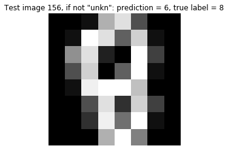

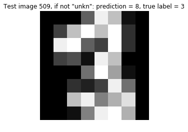

```python
unknowns = list(np.where(y_predict_u == C_u[-1])[0])

for u in unknowns:
    plt.figure()
    plt.imshow(X_test[u,:].reshape(8,8), cmap='gray')
    plt.axis('off')
    plt.title('Test image {}, if not "unkn": prediction = {}, true label = {}'.format(u,y_predict[u],Y_test[u]))
    plt.show()
```